# asangar-FinalExam

### FINAL EXAM

**Name:** Amol Dattatray Sangar (asangar)

### Problem 1.1 [2 pt.]

Consider an undirected graph G = (V;E) with edge costs that are all positive and distinct. Let T be a minimum spanning tree for graph G. Let P be a shortest path from s to t, where s; t 2 V . Which of the following statements is correct?

(A) Suppose each edge weight is increased by 1, the minimum spanning tree T will not change

(B) Suppose each edge weight is increased by 1, the shortest path P between node s and t will not change

(C) The edge with heaviest edge cost cannot be in minimum spanning tree T

(D) The edges included in shortest path P will also be in minimum spanning tree T

**Answer - (A) Suppose each edge weight is increased by 1, the minimum spanning tree T will not change**

### Problem 1.2 [2 pt.]

Which of the following statements about a tree of n nodes is wrong?

(A) A tree is a connected graph with at most n - 1 edges

(B) Removing the root node is the only way to disconnect the tree

(C) Adding one edge in the tree will create exactly one cycle

(D) There is one unique path between every pair of vertices

**Answer - (B) Removing the root node is the only way to disconnect the tree**

### Problem 1.3 [2 pt.]

Which of the following statements about a Binary Search Tree with distinct n elements is wrong?

(A) The left child is always lesser than its parent

(B) The smallest element is always at the leaf of the tree

(C) A search operation takes O(n) time

(D) Every non-root node has exactly one parent

**Answer - (B) The smallest element is always at the leaf of the tree**

### Problem 1.4 [2 pt.]

The algorithm in concern has a time complexity of O(n^2). The algorithm takes 40 seconds to run with input size 10. How much time it will require to run with input size 30?

(A) 2 minutes

(B) 4 minutes

(C) 5 minutes

(D) 6 minutes

**Answer - (D) 6 minutes**

### Problem 1.5 [2 pt.]

Consider the following unsorted array of strings, R = {cat, him, ham, bat}. What will be the order of elements of R after the first iteration of LSD Radix sort if we want to sort the array in an ascending order?

(A) {ham, him, cat, bat}

(B) {him, ham, cat, bat}

(C) {him, ham, bat, cat}

(D) {ham, him, bat, cat}

**Answer - (B) {him, ham, cat, bat}**

### Problem 1.6 [2 pt.]

Using Brute-Force pattern matching algorithm, which pattern below will give you the fastest match with the given string “abacaabaccabacabaabb"?

(A) bacab

(B) cabac

(C) baabb

(D) bacca

**Answer - (D) bacca**

### Problem 2 [5 pt.]

Let G = (V;E) be a connected directed graph with non-negative edge weights. Let s and t be vertices of G. We delete c (not a constant number) edges in G to get a subgraph H. Suppose we want to add back exactly one deleted edge into H, so that the shortest path from s to t in the resulting graph is as short as possible.

Describe an algorithm that chooses the best edge to reinsert. Your algorithm should run in O(mlog n) time in which m is the number of edges and n is the number of vertices in G.

Hint 1: Dijkstra’s algorithm runs in O(mlog n) time on graph G.

Hint 2: Number of deleted edges c is not a constant number, so running Dijkstra’s algorithm c times will result in O(c mlog n) running time.

**Answer**

To determine which deleted edge to add, we need to know the minimum distance to every node in the graph.

We can do this by running Dijkstra’s algorithm in O(mlog n) time on graph H.

Algorithm -

1. Run Dijkstra's Algorithm on H, with source s to get minimum distances for all vertices from s. Let dist'[0], dist'[1],...,dist'[n-1] be the minimum distances from s to all other vertices (generated by Dijkstra's Algo)
2. Reverse edges in graph H (new graph H*)
3. Run Dijkstra's Algorithm on H*, with source t to get minimum distances for all vertices from t. Let dist*[0], dist*[1],...,dist*[n-1] be the minimum distances from t to all other vertices (generated by Dijkstra's Algo)
4. Let w[0], w[1],...,w[c-1] be the weights of all the c edges that are deleted.
5. Let k=0,1,2,...,c-1. For each deleted edge w[k] which connects vertex indices i and j, calculate: cost[k]=w[k]+dist'(i)+dist*(j)
6. return vertex i, vertex j corresponding to the minimum cost[k]

Time complexity is running Dijkstra’s algorithm two times i.e. O(2*m*logn) = O(m*logn)

### Problem 3 [5 pt.]

Let G = (V,E) be a connected undirected graph with m edges and n nodes. If we remove a node v from G, we get a subgraph Gv. Given a graph G and a node v, how can you know if subgraph Gv is connected or not? Please describe a O(m+n) algorithm to decide the connectivity of Gv.

```
Answer -

To determine if Gv is connected or not, check if there's any node in G connected to any node in Gv by an edge.

If there's an edge, then Gv is connected to G otherwise its a disconnected graph.

To do this, we can use traversal algorithms like DFS or BFS to see if they visit all nodes or not. To run it in O(m+n) time, we can maintain an adjacency list that stores edges from every node. Thus, we are checking the whole graph only once in O(m+n) time to determine the connectivity.
```

```python
class Graph:
    def __init__(self, edges, n):

        self.adjList = [[] for _ in range(n)]

        # add edges to the directed graph
        for (src, dest) in edges:
            self.adjList[src].append(dest)

def DFS(graph, v, visited):
    visited[v] = True

    for u in graph.adjList[v]:
        if not visited[u]:
            DFS(graph, u, visited)

# Function to check graph connectivity
def isConnected(graph,n):
    # n is no of nodes
    visited = [False] * n
    v = 0

    DFS(graph, v, visited)

    for v in visited:
        if not v:
            return False

    return True
```

### Problem 4

A long string (10,000 characters) consists of four characters: A, T, G, C; they appear with fre- quency 1/2, 1/4, 1/8 and 1/8, respectively.

(a) What is the Huffman encoding for each character in the alphabet? Draw the Huffman encoding tree for each step of the algorithm. The final Huffman encoding tree should look like the following tree. You may draw by hand and upload a picture.

(b) Originally each character is represented in two bits. How many bits are saved if we use the new encoding scheme we obtained in the previous question?

Answer -

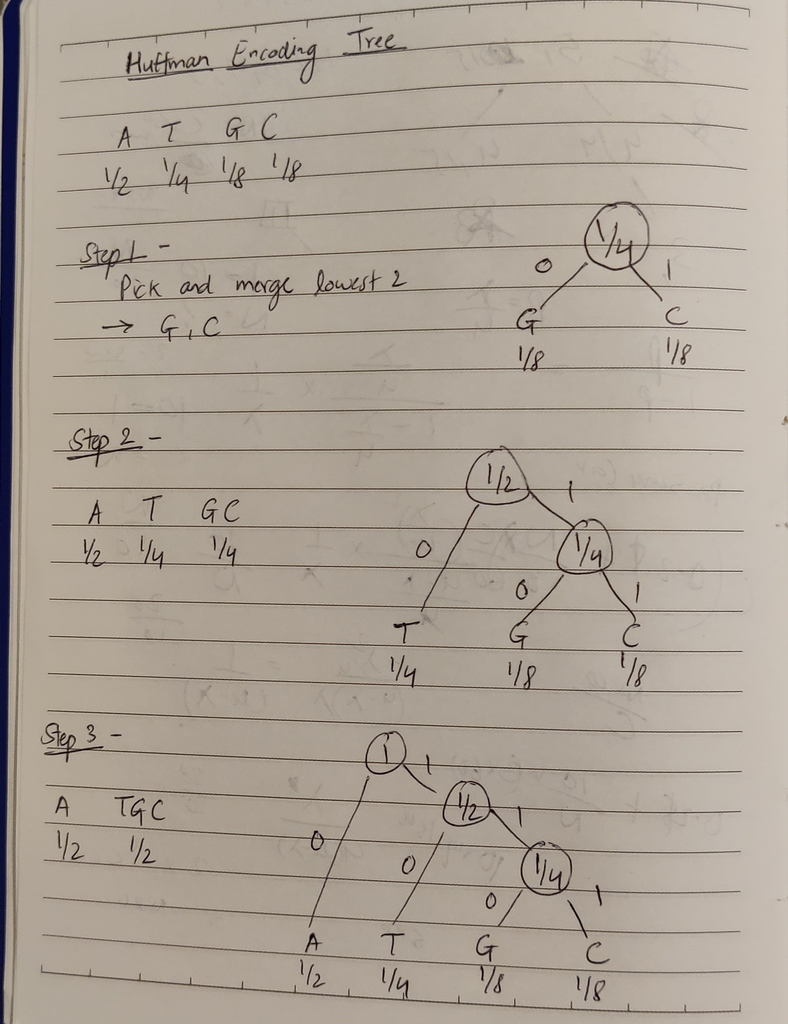

#### Part (a) - Huffman Encoding Output:

A - 0

T - 10

G - 110

C - 111

#### Part (b) - Total Bits Saved

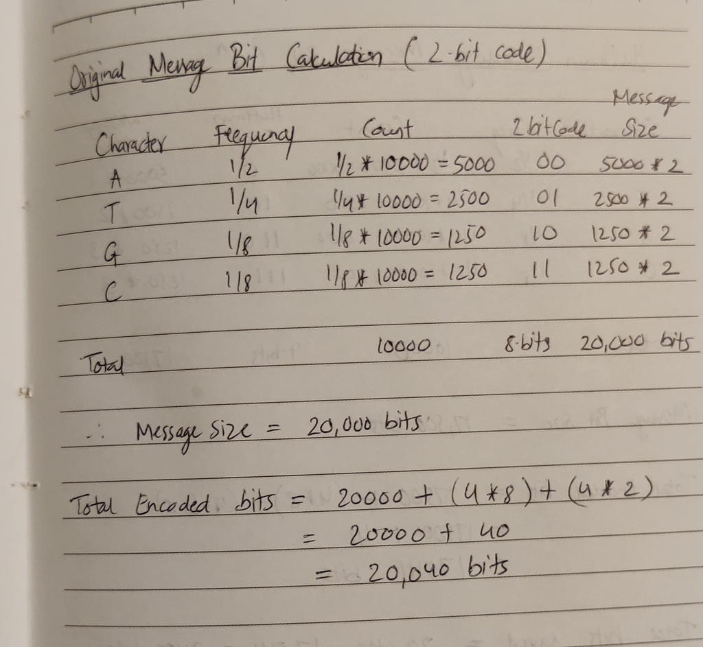

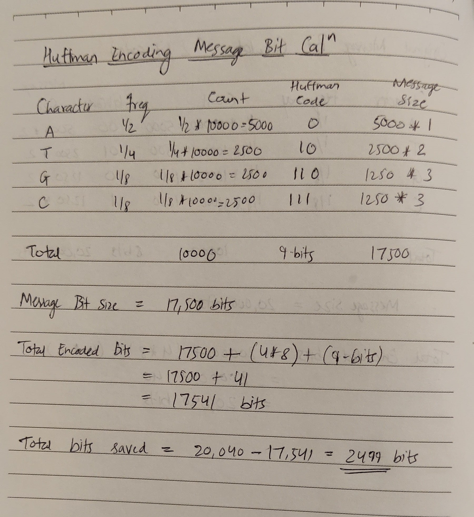

### Problem 5

Let G = (V,E) be a undirected graph with m edges and n nodes; and let T = (V,E′) be its minimum spanning tree. All edge weights are distinct. Assume we remove an edge (u, v) ∈ E′ from graph G. Describe an algorithm to update the minimum spanning tree in O(m) time.

1. Hint 1: The removal of edge (u, v) disconnects the spanning tree T in to two set of nodes A and B. Without a loss of generality, we may assume u ∈ A and v ∈ B.
2. Hint 2: We need to find the smallest weight edge whose one end node in A and the other end node in B.
3. Hint 3: In order to get full marks, you need to state clearly what algorithm you use to find set A and B; what data structure you use to efficiently look up for target edge; and what are the running time of each portion of your algorithm.

**Answer**

Algorithm -

1. Delete edge between node u and node v
2. To find set A and B, we can run DFS algorithm from nodes u and v respectively. DFS will visit all nodes and thus we can determine the disconnected trees.
3. Perform union operation on the two sets i.e. set A and set B
4. Iterate through all edges of the graph and check if source and destination nodes are present in same or different sets
5. If source and destination nodes are present in different sets, then we update the edge having minimum weight that connects both sets.

Time Complexity - DFS will take O(n) time to traverse all nodes. Union operation takes O(1) time.

Since nodes are always less in number than the edges we can say that the overall time complexity is O(m).

### Problem 6

We would like to solve word search puzzle problem in which we are given a N by N character board and N words. In the word search puzzle, the N words may be placed horizontally, vertically, or diagonally in the world puzzle board. Your task is to find all the N words.

If you are not familiar with word search puzzle, please refer to https://thewordsearch. com for more details. Please describe a O(N^3) algorithm to solve this problem. You need to specify what data structure you use and what are the time complexity at each step.

Answer -

**Data structure used: Trie data structure + DFS for backtracking**

The word search is performed in 2 steps -

1. Insertion of all words into a Trie
2. In the N*N matrix, at end index we can perform DFS backtracking search in all 8 directions (left, right, top, bottom, top right diagonal, top left diagonal, bottom right diagonal, bottom left diagonal) to find all the words

**Time complexity = O(N^2 *8*N) + O(N^2) = O(N^3)**

```python
Algorithm: Word_search

#========================================================
Step 1 : construct_trie (O(N^2))

Input: N words
Output: Trie comprising all N words

Create a new trie node # Add all words as characters to the trie structure

for word in words:
    insert each word into trie node # Store all words in a trie data structure

#========================================================
Step 2: find_words (O(N^2) * 8*N)
# Input: N*N matrix, N words
# Output: Result with all N words found in the matrix word puzzle

for i in rows:   # (O(N))
    for j in columns:  # O(N)
        # At each index we can move in 8 directions
        res = dfs_backtrack_search for words in trie  # O(8*N)
```

### Problem 7 [5 pt.]

What is the time complexity of the function calc in big-Oh? What is the return value k in terms of big-Oh notion? For full credit please show your work step by step.

Answer -

Time complexity of calc() is dependent upon 2 loops. First loop takes O(n/2) time (n/2 -> n). The second loop takes O(log.n) time since j is multiplied by 2 on every iteration and thus the overall iterations keeps getting reduced by half.

Thus overall time complexity is O(n * log.n) because of the dominant terms

The return value of k is n/4 *O(n* log.n)

```python
def calc(n):
    k = 0
    i = n/2
    while(i<=n):     # Time complexity here is O(n/2)
        i = i + 1
        j = 2
        while(j<=n):    # Time complexity here is O(log.n)
            j = j * 2
            k = k + n/2    # Result = n/4 * O(n * log.n)
    return k
```

### Problem 8 [5 pt.]

What are the advantages of QuickSort over MergeSort? If we want to sort a linked list of elements, which one between them should we choose? Please explain your answer.

Answer -

**Advantages of QuickSort over MergeSort**

1. Quicksort is an in-place sorting algorithm i.e. it does not need additional space to perform sorting. Whereas mergesort requires extra/temporary space to perform sorting operations such as merging two arrays.
1. It is more efficient on smaller sized arrays when compared with MergeSort
1. Quicksort has better locality of reference than mergesort, which means that the accesses performed in quicksort are usually faster than the corresponding accesses in mergesort.

**To sort a linked list, MergeSort is usually preferred because of the following reasons**

1. It makes fewer total comparisons when compared with QuickSort
1. It is also not vulnerable to poor pivot choice
1. Slow random-access performance of a linked list makes QuickSort perform poorly
1. Space complexity is O(1) when ordering linked lists since it only involves manipulating links

### Problem 9 [5 pt.]

Consider a pattern matching problem with string s = “GCATGACTGCGTGACC" and pattern p=“CTGC". Using the Boyer-Moore algorithm find the lowest index i within s at which the matched (with p) substring begins. Follow the simplified Boyer-Moore algorithm step by step to find the value of i as well as demonstrate how many comparisons are made.

Answer -

```
Look-up Table
c       |  A  C  G  T
last(c) | -1  3  2  1


0 1 2 3 4 5 6 7 8 9 - - - - - -
G C A T G A C T G C G T G A C C
C T G C                             - Comparison 1 (T with C)
    C T G C                         - Comparison 2 (A with C)
            C T G C                 - Comparison 3,4,5,6 (CTGC with CTGC) Pattern Matched at index 6
```

Thus, the pattern is matched at index 6 with 6 overall comparisons

### Problem 10 [5 pt.]

Consider an array of n positive integers, A = fa1; a2; :::; ang and a positive integer m. Using a top down dynamic programming method, design an algorithms that answers us if some subset of A add up to m where you can use each a-n at most once.

For example, a list of 5 positive integers A = f3; 7; 11; 15; 21g and the given integer m = 25. Your designed problem will answer True as a subset of A, f3; 7; 15g, sums to the given value of m.

Prove the correctness of your algorithm and show the computation time with regards to big-Oh notion.

Answer -

```
def isSubsetSum(A, n_items, reqd_sum):

    #Base Case 1
    if(reqd_sum < 0:
        return False
    elif (reqd_sum == 0):
        return True

    #Base Case 2
    if (n_items == 0):
        return False

    #If last element is greater than the required sum, then ignore it
    if (A[n_items - 1] > reqd_sum):
        return isSubsetSum(set, n_items - 1, reqd_sum)

    return isSubsetSum(A, n_items-1, reqd_sum) or isSubsetSum(A, n_items-1, reqd_sum-set[n_items-1])
```

**Time complexity**

Since there are two branches for every element, the time to expand the whole tree thus takes 2^n time i.e. **exponential time**.

**Proof**

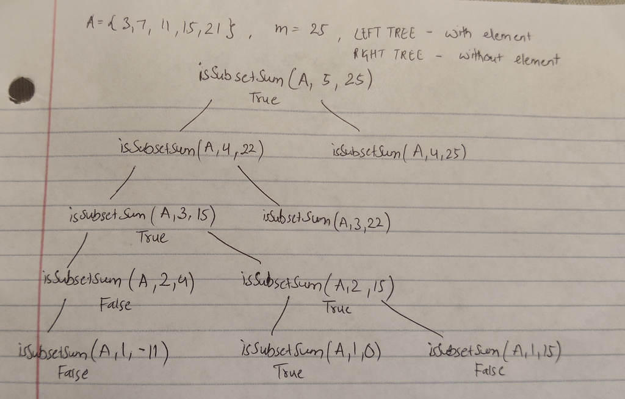

We can see in the tree that every parent has 2 children which decides whether or not there exists a solution which is then propagated upwards till the root node.

### Problem 11 [5 pt.]

• What is the length of the longest common subsequence? Explain. Answer this question on the perspective of just by looking at the values of the table L.

**Answer**

```
The longest common subsequence is of LENGTH 6 as it is present at the bottom right-most cell of the table L i.e. L[9][11]. The reason to select this cell is because the table is filled one cell at a time and uses previous results.
```

• Show the path, in L(i; j), that a tracking algorithm will take to recover the longest common subsequence starting from L(9; 11). Given: the characters of X with indices {4; 5; 6; 7; 8; 9} match with the characters of Y with indices {0; 3; 4; 5; 7; 11}.

Note: Traverse the 2D array starting from L[9][11]. Do following for every cell L[i][j]:

• If characters (in X and Y ) corresponding to L[i][j] are same (Or X[i - 1] == Y [j - 1]), then include this character as part of LCS and move to L[i - 1][j - 1] cell.

• Else compare value of L[i][j] with L[i - 1][j] and L[i][j - 1] and go in direction of greater value.

**Answer**

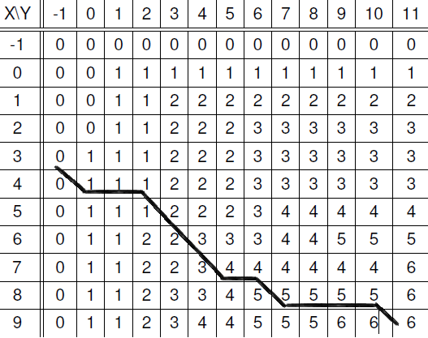

To find the path, we backtrack from the bottom rightmost cell and go diagonally when we find matching row and column characters. Otherwise, we go along the direction of bigger number.

## Programming Problem 1 [20 pt.]

This programming question involves three previous lab sessions: Mergesort, Kruskal’s Algorithm and Depth-firth Search. At the beginning, you were given a detailed representation of a graph. You need to first find the minimum spanning tree of a given graph. Then we add one edge on the MST which will create a cycle. Your second task is to find the cycle on the modified MST. Please refer the details in file "MST-student.ipynb".

# Final exam programming problem

In this problem, you will work on the following:

- For a graph G, you will compute its MST
- We will add an edge into the MST and you should be able to quickly update the MST

To solve this problem, you may consult three lab sessions:

- Merge sort (We will sort the edges using merge sort)
- MST (Kruskal's algorithm)
- DFS (To find a cycle on a graph)

```python
import random
import copy
```

## Part 1

You must work with the provided data structures. You may use your own data structures if they are not defined here.

```python
# Define graph edge
class Edge:
    def __init__(self, node1, node2, weight=1.0):
        self.node1 = node1
        self.node2 = node2
        self.weight = weight

    def __lt__(self, other):
        selfPriority = self.weight
        otherPriority = other.weight
        return selfPriority < otherPriority
```

```python
# Define an undirected graph
class UndirectedGraph:
    def __init__(self, n):
        self.num_nodes = n
        self.nodes = [set() for i in range(n)]
        self.edges = []

    # edge node1 <--> node2 (undirected)
    def insert(self, node1, node2, weight=1.0):
        self.nodes[node1].add(node2)
        self.nodes[node2].add(node1)
        self.edges.append(Edge(node1, node2, weight))
        self.edges.append(Edge(node2, node1, weight))
```

### Graph representation

- Linked list: self.nodes in class UndirectedGraph (for DFS)
- Edge list: self.edges in class UndirectedGraph (for MST)

```python
# A function to generate a random graph
def generate_graph_and_output_edges(num_nodes, random_seed, num_edge_per_node=3):
    random.seed(random_seed)
    graph = UndirectedGraph(num_nodes)
    edge_list = []
    for i in range(num_nodes):
        while len(graph.nodes[i]) < num_edge_per_node:
            node = random.randint(0, num_nodes-1)
            if node != i and (node not in graph.nodes[i]):
                weight = random.random()
                graph.insert(i, node, weight)
    return graph
```

### A small sample graph

This is a sample graph so you can learn how graph is represented in this problem

```python
# Generate the graph
graph_sample = generate_graph_and_output_edges(5, 100, 2)

# print nodes represented in linked list
print(graph_sample.nodes)

# print edges represented in edge list
for e in graph_sample.edges:
    print("{:2d}, {:2d}, {:.5f}".format(e.node1, e.node2, e.weight))
```

```
[{1, 2, 3}, {0, 3, 4}, {0, 3, 4}, {0, 1, 2}, {1, 2}]
 0,  1, 0.45953
 1,  0, 0.45953
 0,  3, 0.73196
 3,  0, 0.73196
 1,  3, 0.50687
 3,  1, 0.50687
 2,  0, 0.53290
 0,  2, 0.53290
 2,  3, 0.26342
 3,  2, 0.26342
 4,  1, 0.33535
 1,  4, 0.33535
 4,  2, 0.83890
 2,  4, 0.83890
```

```python
# Union Find data structure is provided to support Kruskal
class UnionFind:
    def __init__(self, num_nodes):
        # Initially position[i] = i
        self.position = [i for i in range(num_nodes)]

    # Return the cluster index
    def find(self, node):
        if self.position[node] == node:
            return node
        else:
            self.position[node] = self.find(self.position[node])
            return self.position[node]

    def union(self, node1, node2):
        a = self.find(node1)
        b = self.find(node2)
        # no need to union
        if a == b:
            return
        # union is needed
        else:
            if a < b:
                self.position[b] = a
            else:
                self.position[a] = b
```

## Part 2

Find a MST for a given graph.

The returned MST should be in edge list format. (Just like what we did in the lab)

When sorting the graph.edges, you must use Merge Sort. (We used PriorityQueue in the lab)

```python
# Implement MergeSort

# Your merge sort should returend a sorted list of A
def merge(X, Y):
    m = len(X)
    n = len(Y)

    X.sort()
    Y.sort()

    res=[]
    i=0
    j=0
    while (i<len(X) and j<len(Y)):
        if(X[i] < Y[j]):
            res.append(X[i])
            i+=1
        else:
            res.append(Y[j])
            j+=1

    while i<len(X):
        res.append(X[i])
        i+=1

    while j<len(Y):
        res.append(Y[j])
        j+=1

    return res


def MergeSort(A):
    n = len(A)

    single_data_list=[]

    for i,val in enumerate(A):
        single_data_list.append([val])

    while len(single_data_list) != 1:
        temp=[]
        for i in range(0,len(single_data_list)-1,2):
            temp.append(merge(single_data_list[i],single_data_list[i+1]))

        if(len(single_data_list)%2 != 0):
            temp.append(single_data_list[len(single_data_list)-1])

        single_data_list = temp

    return [x for x in single_data_list[0]]
```

```python
# Implement Kruskal

# returned MST is a list of class Edge
def kruskal(graph):
    MST = []
    uf = UnionFind(graph.num_nodes)

    sorted_edge_list = MergeSort(graph.edges)

    n = len(sorted_edge_list)

    while(len(MST) != n-1 and len(sorted_edge_list) > 0):
        edge = sorted_edge_list.pop(0)
        edge_a = edge.node1
        edge_b = edge.node2

        a = uf.find(edge_a)
        b = uf.find(edge_b)

        if (a != b):
            MST.append(edge)
            uf.union(edge_a, edge_b)

    return MST
```

## Part 3

A new edge (2, 19) with weight 0.2

We need to quickly update the old MST to get a new MST

```python
# Construct a graph from edge list. This is given to you.

# We assume num_nodes is given for simplicity.
def generate_graph_from_edges(edge_list, num_nodes):
    graph = UndirectedGraph(num_nodes)
    for e in edge_list:
        graph.insert(e.node1, e.node2, e.weight)
    return graph
```

### Algorithm

- We add the new edge to the old MST which will generate a cycle
- The cycle consists at least three edges
- The edge with the largest weight should be removed
- You ONLY need to print out the edges on the cycle to get full marks (the two end nodes and the weight)

### Sample example

- We have a MST for a graph of 3 nodes
- MST has edge (0, 1, 0.12) and (0, 2, 0.23)
- We add a new edge (1, 2, 0.2)
- A cycle of three edges is generated
- We need to delete edge (0, 2, 0.23)

### How to use DFS to find the cycle

- Suppose the new edge is (2, 19, 0.2)
- If we DFS from node 2, we will eventurally hit node 19
- You need to properly append and pop on "cycle_edges" during DFS
- The "cycle_edge" should contain the final path from 2 to 19

```python
# Use DFS to detect the cycle

# You may add more arguments in dfs_recursive() for your convenience

def dfs(graph, starting_node, stopping_node):
    visited_nodes = [False for i in range(graph.num_nodes)]
    cycle_edges = []

    dfs_recursive(graph, starting_node, visited_nodes, cycle_edges, stopping_node, starting_node)

    # The following is for demonstration purpose
    print("We found {:d} edges from node {:d} to node {:d}"
          .format(len(cycle_edges), starting_node, stopping_node))

    for e in cycle_edges:
        '''
        print the two end nodes of the edge
            the weight information is not known so you do not need to output

        You may change the following print statement
            if you did not use Edge class
        '''
        print("{:2d}, {:2d}".format(e.node1, e.node2))


def dfs_recursive(graph, starting_node, visited_nodes, cycle_edges, stopping_node, v, parent=-1):
    visited_nodes[v] = True

    for w in sorted(graph.nodes[v]):

        if not visited_nodes[w]:
            if dfs_recursive(graph, starting_node, visited_nodes, cycle_edges, stopping_node, w, v):
                cycle_edges.insert(0,Edge(v,w))
                return True

        # if `w` is already visited, and `w` is not a parent
        elif w != parent:
            return True

    return False
```

**Explanation**

In DFS recursive, we keep track of every visited node. To find the cycle in the DFS, we are also keeping track of parent of the visited nodes.

During the DFS, if we find any node that is already visited and is not a parent, then we can say that there is a cycle present.

## Part 4 Test code

Do NOT modify the code in this part.

```python
graph_mst = generate_graph_and_output_edges(20, 10, 5)
MST = kruskal(graph_mst)

for e in MST:
    print("{:2d}, {:2d}, {:.5f}".format(e.node1, e.node2, e.weight))
```

```
18,  3, 0.00406
 1,  5, 0.03175
18,  0, 0.03259
 5,  0, 0.03440
11,  1, 0.04456
 2, 18, 0.05057
15, 13, 0.06277
15,  4, 0.06499
 7, 11, 0.07993
 4, 19, 0.10876
 8,  9, 0.14351
16,  5, 0.15642
 9, 10, 0.16494
14,  7, 0.16636
16,  9, 0.17846
 4,  3, 0.19495
 4,  6, 0.38442
 5, 12, 0.39059
 0, 17, 0.43858
```

```python
def find_the_cycle(MST, new_edge, num_nodes):
    MST.append(new_edge)

    # construct graph from edge list
    graph_cycle = generate_graph_from_edges(MST, num_nodes)

    # call dfs to find a path from node1 to node2
    dfs(graph_cycle, new_edge.node1, new_edge.node2)
```

```python
find_the_cycle(MST, Edge(2, 19, 0.2), 20)
```

```
We found 4 edges from node 2 to node 19
 2, 18
18,  3
 3,  4
 4, 19
```

```python
# Instead we can add edge (3, 14, 0.1)
find_the_cycle(MST, Edge(3, 14, 0.1), 20)
```

```
We found 10 edges from node 3 to node 14
 3,  4
 4, 19
19,  2
 2, 18
18,  0
 0,  5
 5,  1
 1, 11
11,  7
 7, 14
```

### Hint

If you run the following codes,

```python
graph_hint = generate_graph_and_output_edges(10, 1, 2)

mst = kruskal(graph_hint)

print("The minimum spanning tree:")
for e in mst:
    print("{:2d}, {:2d}, {:.5f}".format(e.node1, e.node2, e.weight))

find_the_cycle(mst, Edge(1, 8, 0.2), 10)
```

```
The minimum spanning tree:
 8,  6, 0.00920
 0,  5, 0.02232
 1,  0, 0.25507
 6,  3, 0.43277
 1,  3, 0.48786
 0,  9, 0.52763
 2,  0, 0.56920
 3,  4, 0.59115
 7,  2, 0.65159
We found 3 edges from node 1 to node 8
 1,  3
 3,  6
 6,  8
```

```python
# this is the results you should get:
'''
The minimum spanning tree:
 8,  6, 0.00920
 0,  5, 0.02232
 1,  0, 0.25507
 6,  3, 0.43277
 1,  3, 0.48786
 0,  9, 0.52763
 2,  0, 0.56920
 3,  4, 0.59115
 7,  2, 0.65159
We found 3 edges from node 1 to node 8
 1,  3
 3,  6
 6,  8
'''
print()
```

### Programming Problem 2 [18 pt.]

A modified knapsack problem is that for a given set of positive integers {a1, a2, ..., an}, a knap- sack of size s, find a subset A of {a1, a2, ..., an} such that the sum of elements in A is the largest, but at most s. Write a program using Python to solve this problem using a top down dynamic programming method.

Test your program for the following modified knapsack problem: Input list: {5, 23, 27, 37, 48, 51, 63, 67, 71, 75, 70, 83, 889, 91, 101, 112, 121, 132, 137, 141, 143, 147, 153, 159, 171, 181, 190, 191} with knapsack size s = 762.  
Print out a subset along with the sum of its elements so that the sum has the closest distance to 762.

```python
import copy
```

```python
def trace_subset(subset, input_list, max_size):
    knapsack_subset = set()

    size = copy.deepcopy(max_size)

    for i in range(len(input_list)):
        key = (i, size)
        if key in subset.keys():
            edge_weight = subset.get(key)[1]
            if edge_weight:
                size -= input_list[i]
                print(f"Weight {input_list[i]} added from index {i}")
                knapsack_subset.add(input_list[i])

    return knapsack_subset
```

```python
def knapsack_subset_recursive(subset, input_list, size, current_index):
    if size <= 0 or current_index >= len(input_list):
        return 0

    key = (current_index, size)
    if (key in subset.keys()):
        return subset.get(key)[0]

    # Left Branch - Value included
    include = 0
    current_element = input_list[current_index]
    if (current_element <= size):
        include = current_element + knapsack_subset_recursive(subset, input_list, (size - current_element), current_index+1)

    # Right Branch - Value excluded
    exclude = knapsack_subset_recursion(subset, input_list, size, 1 + current_index)

    edge_weight = 0
    if (include > exclude):
        edge_weight = 1
    subset[(current_index, size)] = (max(include, exclude), edge_weight)

    return max(include, exclude)
```

```python
def knapsack_subset(input_list, max_size):
    subset = {}
    current_index = 0
    knapsack_value = knapsack_subset_recursion(subset, input_list, max_size, current_index)
    knapsack_subset = trace_subset(subset, input_list, max_size)

    return (knapsack_value, knapsack_subset)
```

```python
A = [5, 23, 27, 37, 48, 51, 63, 67, 71, 75, 70, 83, 889, 91, 101, 112, 121, 132, 137, 141, 143, 147, 153, 159, 171, 181, 190, 191]
s = 762

print("Knapsack Size:", s)

print()
(knapsack_value, knapsack_subset)= knapsack_subset(A, s)
print("\nOutput: ")
print("Knapsack value: {}".format(knapsack_value))
print("Knapsack subset: {}".format(knapsack_subset))
```

[output not shown]

### Explanation:

To find the closest value to the knapsack using top down approach, we are branching the input elements where values are subtracted from the knapsack value in the left branch and kept as it is in the right branch. We recursively do this operation until we run out of elements. To make this recursive approach dynamic, max elements are picked up from the memory saved in the form of a dictionary. Once the max knapsack value is calculated, dictionary lookup is performed to get all index values that forms the final knapsack subset.